# Target-seq analysis - Patient IF137

scRNAseq analysis

Matthieu Duchmann

2020-11-08

```r
# options(encoding = 'UTF-8')
knitr::opts_chunk$set(
  #size = "tiny",
  echo = TRUE,
  eval = TRUE,
  warning = FALSE,
  message = FALSE,
  results = "asis",
  comment = "")

options(scipen = 12) ## Max number of digits for non-scientific notation
# knitr::asis_output("\\footnotesize")
```

# Creation of Seurat object

```r
#Setting working directory
setwd("/home/maduc/TARGET-seq")

#Import RNA STARSolo data and creation of Seurat Objects
Pt137_RNAseq_count <- read.table("Galaxy4951-[FeatureCount_cDNA_IF137].tabular", sep = "\t", header = T)
## correcting header
colnames(Pt137_RNAseq_count) <- unlist(lapply(str_split(colnames(Pt137_RNAseq_count), pattern = "_"), `[[`, 1))
## geneID as rownames and removing first line/column
rownames(Pt137_RNAseq_count) <- Pt137_RNAseq_count$Geneid
Pt137_RNAseq_count <- Pt137_RNAseq_count[-1,-1]

#Import Seurat metadata table
Pt137_RNAseq_metadata <- read.table("metadata_for_seurat_final.csv", sep = ";", dec = ".", stringsAsFactors = F, header = T)
rownames(Pt137_RNAseq_metadata) <- Pt137_RNAseq_metadata$cell_id_rnaseq
Pt137_RNAseq_metadata <- Pt137_RNAseq_metadata %>% dplyr::select (-cell_id_rnaseq)
Pt137_RNAseq_metadata <- Pt137_RNAseq_metadata[colnames(Pt137_RNAseq_count), ]
#all(rownames(Pt137_RNAseq_metadata) == colnames(Pt137_RNAseq_count))

## creation of the first Seurat Object
Pt137 <- CreateSeuratObject(counts = Pt137_RNAseq_count,
                                   meta.data =  Pt137_RNAseq_metadata,
                                   min.cells = 5,
                                   project = "Pt137")
```

# Pre-processing

## Pre-filtering QC

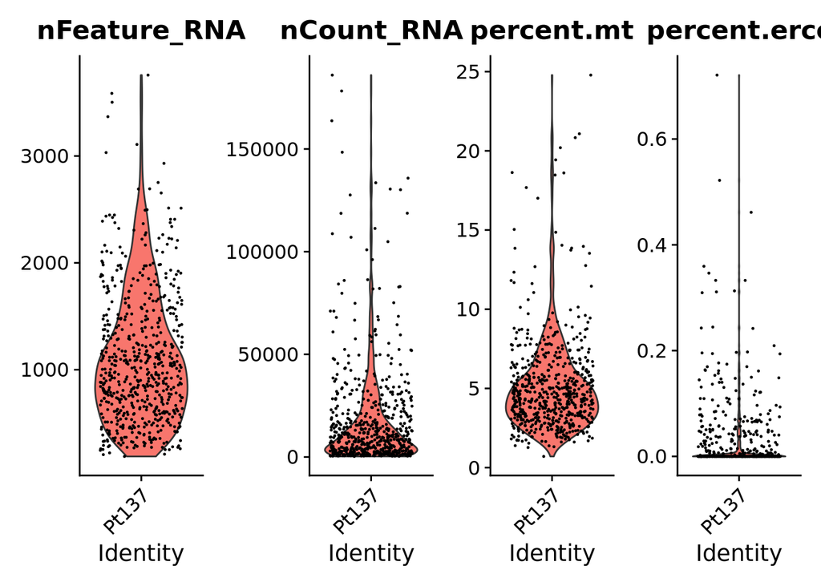

```r
#Visualizing QC parameters
## We calculate the pc of mitochondrial genes
Pt137[["percent.mt"]] <- PercentageFeatureSet(Pt137, pattern = "^MT-")
## We calculate the pc of ercc genes
Pt137[["percent.ercc"]] <- PercentageFeatureSet(Pt137, pattern = "ERCC")
VlnPlot(Pt137, features = c("nFeature_RNA", "nCount_RNA", "percent.mt", "percent.ercc"), pt.size = 0.2, ncol = 4)
```

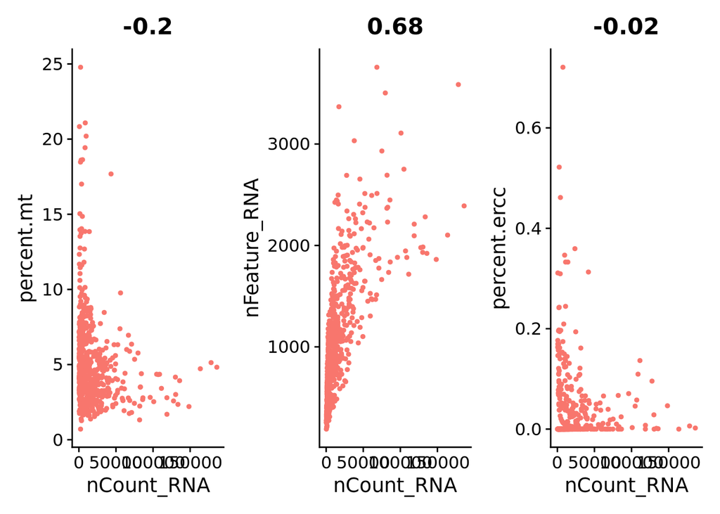

```r
plot1 <- FeatureScatter(Pt137, feature1 = "nCount_RNA", feature2 = "percent.mt") + theme(legend.position='none')
plot2 <- FeatureScatter(Pt137, feature1 = "nCount_RNA", feature2 = "nFeature_RNA") + theme(legend.position='none')
plot3 <- FeatureScatter(Pt137, feature1 = "nCount_RNA", feature2 = "percent.ercc") + theme(legend.position='none')

plot1 + plot2 + plot3
```

```r
rm (plot1, plot2, plot3)
```

## Filtering to keep only good quality cells

We remove ERCC genes from the count matrix. We then only keep cells with nCount_RNA < 50000 & percent.mt < 10

```r
counts_wo_ERCC <- GetAssayData(Pt137, assay = "RNA")
counts_wo_ERCC <- counts_wo_ERCC[- grep (rownames(counts_wo_ERCC), pattern = "ERCC", value = F),]
Pt137_filter <- subset(Pt137, features = rownames(counts_wo_ERCC))

Pt137_filter <- subset(Pt137_filter, subset = nCount_RNA < 50000 & percent.mt < 10)
```

## Post-filtering QC

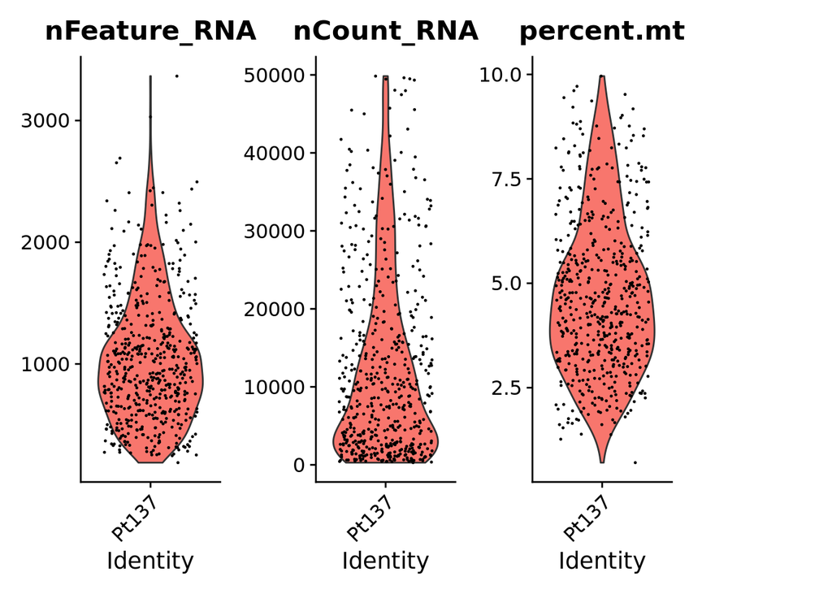

```r
#Visualizing QC parameters
## We calculate the pc of mitochondrial genes
Pt137_filter[["percent.mt"]] <- PercentageFeatureSet(Pt137_filter, pattern = "^MT-")
## We calculate the pc of ercc genes
Pt137_filter[["percent.ercc"]] <- PercentageFeatureSet(Pt137_filter, pattern = "ERCC")
VlnPlot(Pt137_filter, features = c("nFeature_RNA", "nCount_RNA", "percent.mt"), pt.size = 0.2, ncol = 4)
```

# Batch effect identification

## On PCA

There is 2 batch of library preparation for this patient. Does this impact the scRNAseq ?

```r
#Normalization using SCTransform
Pt137_filter_sct <- SCTransform(Pt137_filter)
```

[output not shown]

[output not shown]

[output not shown]

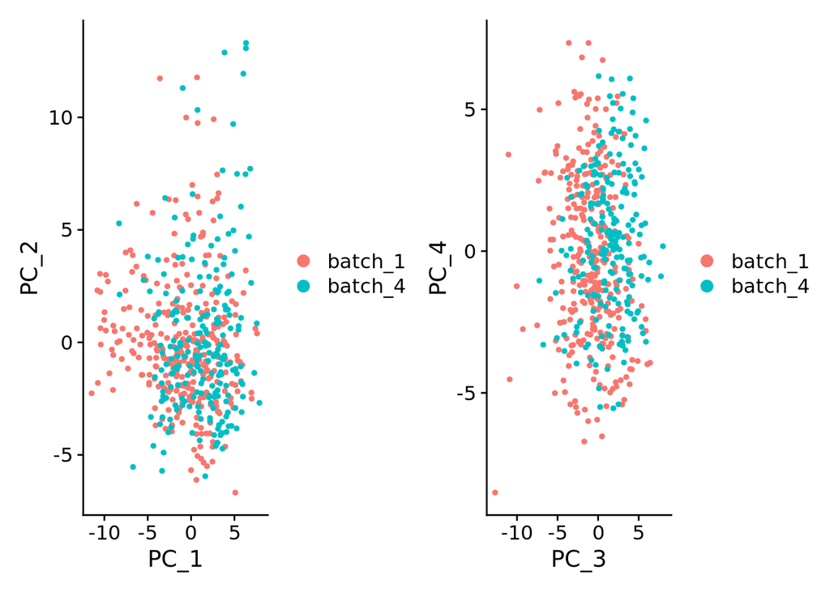

```r
#PCA
Pt137_filter_sct <- RunPCA(Pt137_filter_sct, verbose = FALSE)

#PCA vizualisation
DimPlot(Pt137_filter_sct, group.by = "batch", dims = c(1,2)) + DimPlot(Pt137_filter_sct, group.by = "batch", dims = c(3,4))
```

## On UMAP

The batch effect is quite clear on UMAP. We chose to regress for it by proceding to an integration.

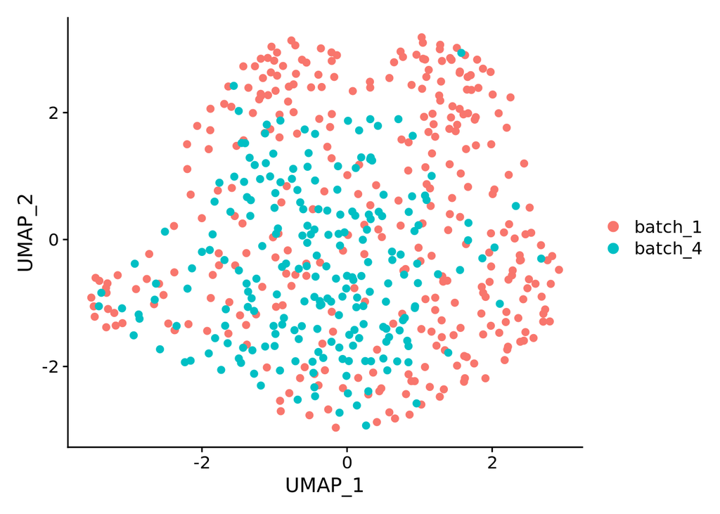

```r
Pt137_filter_sct <- RunUMAP(Pt137_filter_sct, dims = 1:30, verbose = FALSE)
DimPlot(Pt137_filter_sct, group.by = "batch", pt.size = 2)
```

## Shall we take cell-cycle into account ?

Even if the cell-cycle effect is minimal, we chose to regress for it with SCTransform as it drives in both batch strong outliers.

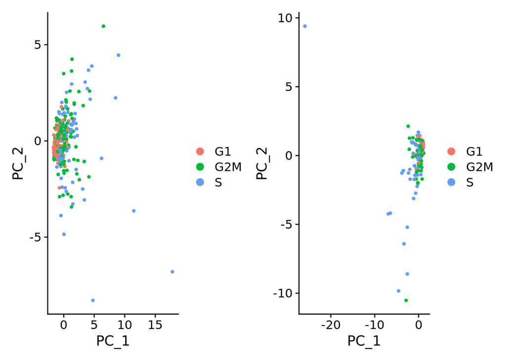

```r
# Splitting object by batch
Pt137.list <- SplitObject(Pt137_filter, split.by = "batch")

#Loading genes related to cell-cycle
s.genes <- cc.genes$s.genes
g2m.genes <- cc.genes$g2m.genes

#Preparation of data for cell-cycle scoring
## Normalization
for (i in 1:length(Pt137.list)) {
    Pt137.list[[i]] <- NormalizeData(Pt137.list[[i]])}

## Scaling
for (i in 1:length(Pt137.list)) {
    Pt137.list[[i]] <- FindVariableFeatures(Pt137.list[[i]], selection.method = "vst")}

for (i in 1:length(Pt137.list)) {
    Pt137.list[[i]] <- ScaleData(Pt137.list[[i]], features = rownames(Pt137.list[[i]]))}

## Cell-cycle scoring
for (i in 1:length(Pt137.list)) {
    Pt137.list[[i]] <- CellCycleScoring(Pt137.list[[i]], s.features = s.genes, g2m.features = g2m.genes, set.ident = TRUE)}

## Vizualisation of cell-cycle effect
DimPlot(RunPCA(Pt137.list[[1]], features = c(s.genes, g2m.genes))) + DimPlot(RunPCA(Pt137.list[[2]], features = c(s.genes, g2m.genes)))
```

## Regression of cell-cycle effect in each dataset

The regression correct effectively the cell-cycle effect (see scales !)

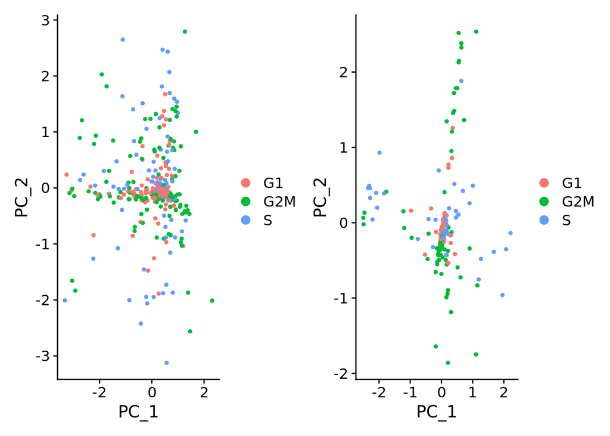

```r
for (i in 1:length(Pt137.list)) {
    Pt137.list[[i]] <- SCTransform(Pt137.list[[i]],  assay = "RNA", vars.to.regress = c("S.Score", "G2M.Score" ), verbose = FALSE)}

DimPlot(RunPCA(Pt137.list[[1]], features = c(s.genes, g2m.genes))) + DimPlot(RunPCA(Pt137.list[[2]], features = c(s.genes, g2m.genes)))
```

# Integration of the 2 batch in a single dataset using IntegrateData

## Integration

```r
#We use as recommended the 2 datasets Normalized and CC corrected using SCTransform
## Selection of variables features for integration
Pt137.features <- SelectIntegrationFeatures(object.list = Pt137.list, nfeatures = 3000)

## Preparing integration
Pt137.list <- PrepSCTIntegration(object.list = Pt137.list, anchor.features = Pt137.features, verbose = FALSE)

## Anchors identification
Pt137.anchors <- FindIntegrationAnchors(object.list = Pt137.list, normalization.method = "SCT",
    anchor.features = Pt137.features, verbose = FALSE)

## Integration
Pt137.integrated <- IntegrateData(anchorset = Pt137.anchors, normalization.method = "SCT",
    verbose = FALSE)
```

## PCA of integrated data

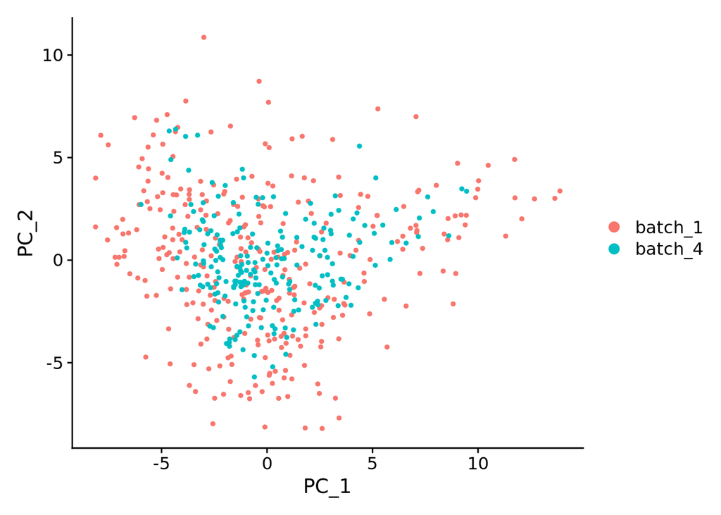

```r
Pt137.integrated<- RunPCA(Pt137.integrated, verbose = FALSE)
DimPlot(Pt137.integrated, group.by = c("batch"))
```

## UMAP of integrated data

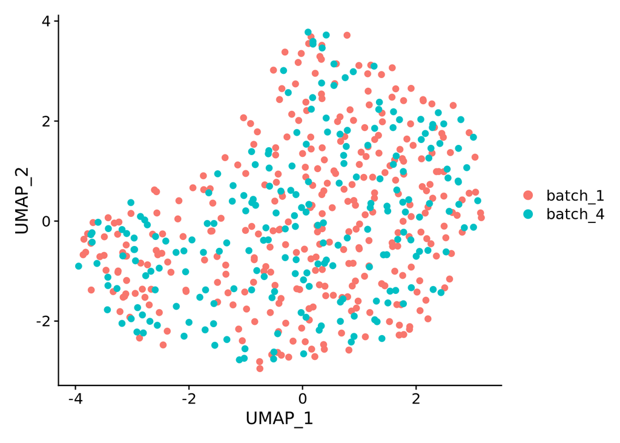

```r
Pt137.integrated <- RunUMAP(Pt137.integrated, dims = 1:30)
 DimPlot(Pt137.integrated, group.by = c("batch"), pt.size = 2)
```

## Cluster identification

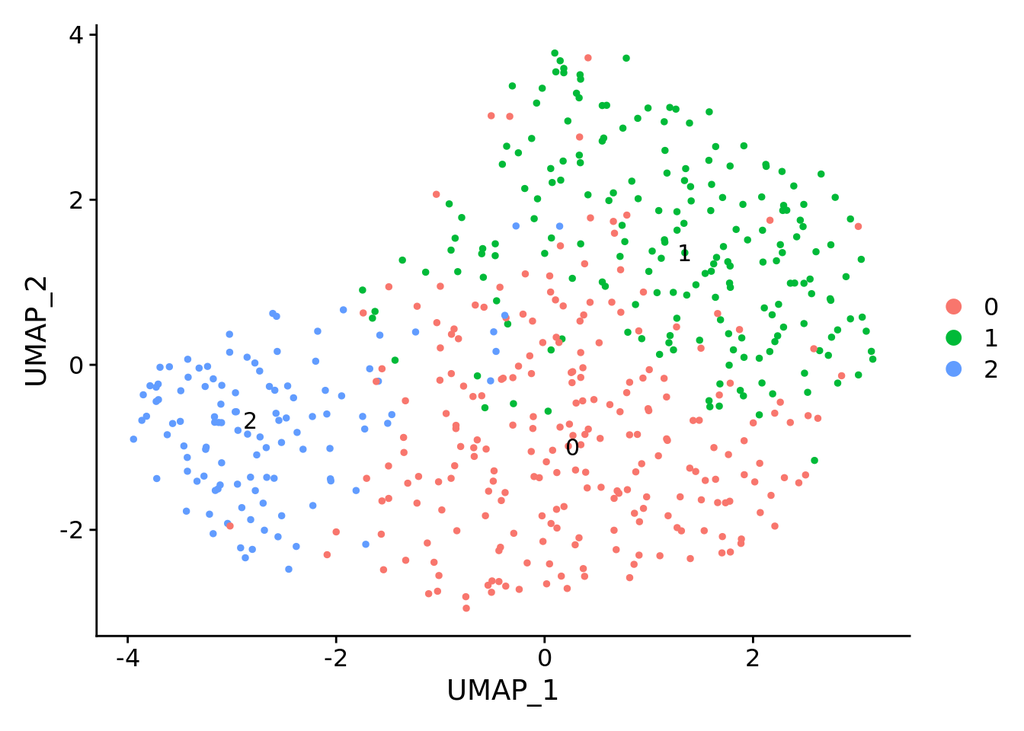

```r
Pt137.integrated <- FindNeighbors(Pt137.integrated, dims = 1:30, verbose = FALSE)
Pt137.integrated <- FindClusters(Pt137.integrated, verbose = FALSE)
DimPlot(Pt137.integrated, label = TRUE)
```

## Is there a clustering of clone ?

As published by the authors, scRNA-seq is unsufficient to cluster clones in single patients.

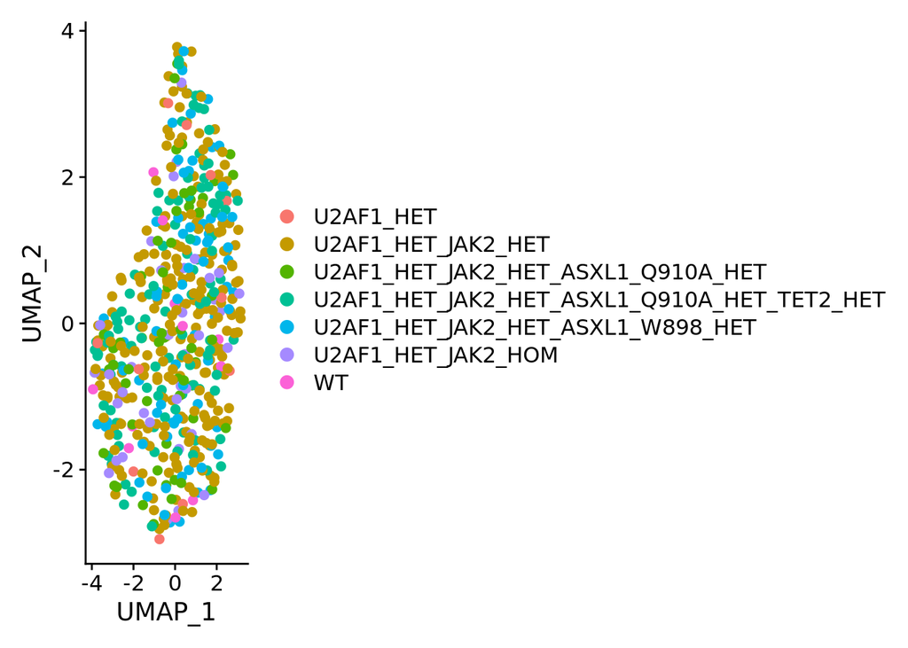

```r
DimPlot(Pt137.integrated, group.by = c("clone"), pt.size = 2)
```

# Integration of genotyping and scRNA-seq : transcirptional differences between the 2 major clones

The 2 major clones are U2AF1_HET_JAK2_HET (n=243 cells) and U2AF1_HET_JAK2_HET_ASXL1_Q910A_HET_TET2_HET (n=107). We want to know what are the main transcriptionnal differences between them. We use for that the FindConservedMarkers in Seurat, that do the DEG analysis in each batch, and do a metanalysis for the p-value. As recommended by Seurat authors, the DEG analysis is realized on RNA assay.

```r
# We set the clone identity as default
Idents(object = Pt137.integrated) <- 'clone'

# We set the RNA assay as default and normalize data
DefaultAssay(Pt137.integrated) <- "RNA"
Pt137.integrated <- NormalizeData(Pt137.integrated, verbose = FALSE)

# We perform the differential expression analysis
DEG <- FindConservedMarkers(Pt137.integrated, ident.1 = c("U2AF1_HET_JAK2_HET_ASXL1_Q910A_HET_TET2_HET"),
                            ident.2 = "U2AF1_HET_JAK2_HET",
                            grouping.var = "batch")

# We select only genes differentially expressed in the 2 assays, and with the same sign for FC
DEG_significatif_all <- DEG %>%
                            filter (sign(batch_4_avg_logFC) == sign(batch_1_avg_logFC)) %>%
                            filter (minimump_p_val < 0.1)
```

## ORA for up-regulated genes

### Using ClusterProfiler and C2 pathway

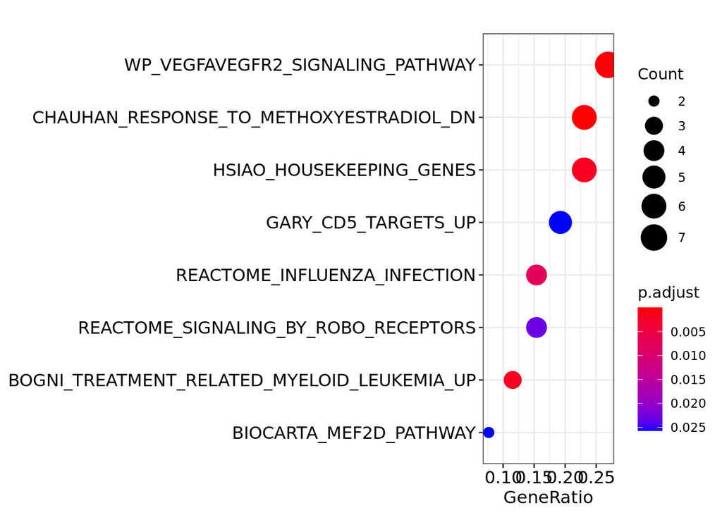

```r
DEG_significatif_up <- bitr(rownames(DEG_significatif_all %>% filter (batch_4_avg_logFC > 0)), fromType="SYMBOL", toType="ENTREZID", OrgDb="org.Hs.eg.db") %>%
                                     dplyr::pull (ENTREZID)

universe <- bitr(rownames(DEG), fromType="SYMBOL", toType="ENTREZID", OrgDb="org.Hs.eg.db") %>%
                                     dplyr::pull (ENTREZID)



m_t2g <- msigdbr(species = "Homo sapiens", category = "C2") %>%
  dplyr::select(gs_name, entrez_gene)


up <- enricher(DEG_significatif_up, TERM2GENE = m_t2g, pvalueCutoff = 0.05)

dotplot(up, showCategory=8) + ggtitle("")
```

## ORA for down-regulated genes

### Using ClusterProfiler and C2 pathway

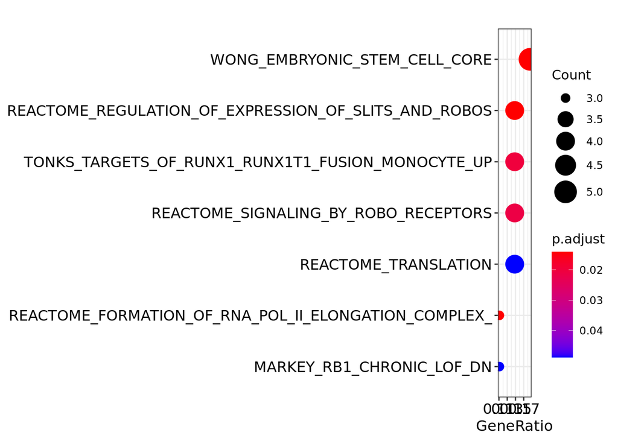

```r
DEG_significatif_down <- bitr(rownames(DEG_significatif_all %>% filter (batch_4_avg_logFC < 0)), fromType="SYMBOL", toType="ENTREZID", OrgDb="org.Hs.eg.db") %>%
                                     dplyr::pull (ENTREZID)



down <- enricher(DEG_significatif_down, TERM2GENE = m_t2g, pvalueCutoff = 0.05)

dotplot(down, showCategory=10) + ggtitle("")
```